# FF_Lab_4

# **Scrape the Location Counts**

## 1. Use the beautifulsoup library to scrape the data (from menuism.com like the link above) on state names and corresponding number of store locations, for the following chains:

Starbucks

Dunkin’ Donuts

Peet’s Coffee & Tea

Tim Horton’s

Panera Bread

Caribou Coffee

Au Bon Pain

The Coffee Bean & Tea Leaf

McDonald’s

```python
!pip install beautifulsoup4
```

```python
import pandas as pd
import re
import requests
from bs4 import BeautifulSoup
response = requests.get("https://www.menuism.com/restaurant-locations/starbucks-coffee-39564")
soup = BeautifulSoup(response.content, "html.parser")
```

### Doing it for starbucks locations

```python
response = requests.get("https://www.menuism.com/restaurant-locations/starbucks-coffee-39564")
soup = BeautifulSoup(response.content, "html.parser")
locations = soup.find_all("li", attrs={"class": ""})

rows = []

for location in locations:
    a_text = location.get_text()
    before = re.findall(r".+(?= Starbucks Coffee locations )", a_text)
    after = re.findall(r"(?<=locations ).+", a_text)

    if before and after:
      state = before[0]
      numloc = after[0]
      numloc = numloc.replace("(","").replace(")","")

      rows.append({
      "state": state,
      "Number_of_Locations": numloc
      })

starbucks = pd.DataFrame(rows)
starbucks
```

### half automating the function for two arguments

```python
def rest_locations(url, restaurant_name):
    response = requests.get(url)
    soup = BeautifulSoup(response.content, "html.parser")
    locations = soup.find_all("li", attrs={"class": ""})

    rows = []

    for location in locations:
        a_text = location.get_text()
        before = re.findall(r".+(?= " + re.escape(restaurant_name) + " locations )", a_text)
        after = re.findall(r"(?<=locations ).+", a_text)

        if before and after:
            state = before[0]
            numloc = after[0]
            numloc = numloc.replace("(","").replace(")","")

            rows.append({
                "state": state,
                "Number_of_Locations": numloc
            })

    return pd.DataFrame(rows)
```

Checking if it works

```python
rest_locations("https://www.menuism.com/restaurant-locations/starbucks-coffee-39564", "Starbucks Coffee")
```

|  | state | Number_of_Locations |
| --- | --- | --- |
| 0 | Alaska | 24 |
| 1 | Alabama | 73 |
| 2 | Arkansas | 33 |
| 3 | Arizona | 279 |
| 4 | California | 2362 |
| 5 | Colorado | 371 |
| 6 | Connecticut | 107 |
| 7 | District of Columbia | 72 |
| 8 | Delaware | 20 |
| 9 | Florida | 616 |
| 10 | Georgia | 248 |
| 11 | Hawaii | 72 |
| 12 | Iowa | 49 |
| 13 | Idaho | 57 |
| 14 | Illinois | 455 |
| 15 | Indiana | 193 |
| 16 | Kansas | 65 |
| 17 | Kentucky | 69 |
| 18 | Louisiana | 76 |
| 19 | Massachusetts | 208 |
| 20 | Maryland | 212 |
| 21 | Maine | 22 |
| 22 | Michigan | 196 |
| 23 | Minnesota | 140 |
| 24 | Missouri | 118 |
| 25 | Mississippi | 23 |
| 26 | Montana | 17 |
| 27 | North Carolina | 181 |
| 28 | North Dakota | 15 |
| 29 | Nebraska | 30 |
| 30 | New Hampshire | 22 |
| 31 | New Jersey | 154 |
| 32 | New Mexico | 56 |
| 33 | Nevada | 188 |
| 34 | New York | 492 |
| 35 | Ohio | 266 |
| 36 | Oklahoma | 62 |
| 37 | Oregon | 279 |
| 38 | Pennsylvania | 279 |
| 39 | Rhode Island | 21 |
| 40 | South Carolina | 65 |
| 41 | South Dakota | 14 |
| 42 | Tennessee | 126 |
| 43 | Texas | 720 |
| 44 | Utah | 59 |
| 45 | Virginia | 300 |
| 46 | Vermont | 6 |
| 47 | Washington | 634 |
| 48 | Wisconsin | 119 |
| 49 | West Virginia | 13 |
| 50 | Wyoming | 16 |
| 51 | County Dublin | 1 |
| 52 | England | 1 |
| 53 | Greater London | 3 |
| 54 | Surrey | 1 |
| 55 | Madrid | 1 |
| 56 | British Columbia | 1 |
| 57 | Ontario | 1 |

### automating the function for just one argument

```python
# scraping restaurant name (second argument)
rest_name = soup.find("meta", attrs={"property":"og:title", "name":'og:title'})
restaurant_name = rest_name.get("content")
restaurant_name = restaurant_name.replace("'", "")
restaurant_name
```

```
'Starbucks Coffee'
```

Putting it all together

```python
def rest_locations(url):
    response = requests.get(url)
    soup = BeautifulSoup(response.content, "html.parser")
    locations = soup.find_all("li", attrs={"class": ""})

    rest_name = soup.find("meta", attrs={"property":"og:title", "name":'og:title'})
    restaurant_name = rest_name.get("content")

    rows = []

    for location in locations:
        a_text = location.get_text()
        before = re.findall(r".+(?= " + re.escape(restaurant_name) + " locations )", a_text)
        after = re.findall(r"(?<=locations ).+", a_text)

        if before and after:
            state = before[0]
            numloc = after[0]
            numloc = numloc.replace("(","").replace(")","")

            rows.append({
                "state": state,
                "Number_of_Locations": numloc
            })

    return pd.DataFrame(rows)
```

### doing it for all restaurants

```python
starbcuks = rest_locations("https://www.menuism.com/restaurant-locations/starbucks-coffee-39564")
Dunkin_Donuts = rest_locations("https://www.menuism.com/restaurant-locations/dunkin-donuts-181624")
peets = rest_locations("https://www.menuism.com/restaurant-locations/peets-coffee-tea-84051")
tim_h = rest_locations("https://www.menuism.com/restaurant-locations/tim-hortons-190025")
Panera_bread = rest_locations("https://www.menuism.com/restaurant-locations/panera-bread-4258")
caribou = rest_locations("https://www.menuism.com/restaurant-locations/caribou-coffee-164861")
au_bon = rest_locations("https://www.menuism.com/restaurant-locations/au-bon-pain-69342")
the_coffee_and = rest_locations("https://www.menuism.com/restaurant-locations/the-coffee-bean-tea-leaf-165988")
mcdonalds = rest_locations("https://www.menuism.com/restaurant-locations/mcdonalds-21019")
```

```
AttributeError: ignored
```

## 2. Write a function stateabb() that takes a state name (assume it’s spelled correctly) and converts it to its state abbreviation. This can be a very simple function.

```python
def stateabb(state):
  states_dic = {
        "Alabama": "AL", "Alaska": "AK", "Arizona": "AZ", "Arkansas": "AR", "California": "CA",
        "Colorado": "CO", "Connecticut": "CT", "Delaware": "DE", "Florida": "FL", "Georgia": "GA",
        "Hawaii": "HI", "Idaho": "ID", "Illinois": "IL", "Indiana": "IN", "Iowa": "IA",
        "Kansas": "KS", "Kentucky": "KY", "Louisiana": "LA", "Maine": "ME", "Maryland": "MD",
        "Massachusetts": "MA", "Michigan": "MI", "Minnesota": "MN", "Mississippi": "MS", "Missouri": "MO",
        "Montana": "MT", "Nebraska": "NE", "Nevada": "NV", "New Hampshire": "NH", "New Jersey": "NJ",
        "New Mexico": "NM", "New York": "NY", "North Carolina": "NC", "North Dakota": "ND", "Ohio": "OH",
        "Oklahoma": "OK", "Oregon": "OR", "Pennsylvania": "PA", "Rhode Island": "RI", "South Carolina": "SC",
        "South Dakota": "SD", "Tennessee": "TN", "Texas": "TX", "Utah": "UT", "Vermont": "VT",
        "Virginia": "VA", "Washington": "WA", "West Virginia": "WV", "Wisconsin": "WI", "Wyoming": "WY"
        }

  stateabb = states_dic.get(state)
  return stateabb

stateabb("California")
```

```
'CA'
```

## 3. Parse, merge and tidy your data so that you have a row for each state and two columns: state abbrevation, location count.

I had done the scrapping before the website went down, now since i can load the data can’t really do this step. But you would first melt all the data to make restaurant name be one collumn, state another, state abbreviation in another and number of location in another and then merge it from all the restaurants.

# **Supplemental Data**

## 4. Scrape the state names and populations from this wikipedia page. Convert the state names to abbreviations and merge these data with your coffee dataset.

```python
response = requests.get("https://simple.wikipedia.org/wiki/List_of_U.S._states_by_population")
soup = BeautifulSoup(response.content, "html.parser")
result = soup.find_all("table")
results = result[0]

rows = []

for result in results.find_all("tr")[1:]:
  cells = result.find_all("td")

  state_tag = cells[2].find("a") or cells[2]
  state = state_tag.get_text()

  pop_tag = cells[3]
  pop = pop_tag.get_text(strip = True)

  rows.append({
          "State": state,
          "Population": pop
          })

population_by_state = pd.DataFrame(rows)
population_by_state['State'] = population_by_state['State'].map(stateabb)
population_by_state
```

|  | State | Population |
| --- | --- | --- |
| 0 | CA | 39,538,223 |
| 1 | TX | 29,145,505 |
| 2 | FL | 21,538,187 |
| 3 | NY | 20,201,249 |
| 4 | PA | 13,002,700 |
| 5 | IL | 12,812,508 |
| 6 | OH | 11,799,448 |
| 7 | GA | 10,711,908 |
| 8 | NC | 10,439,388 |
| 9 | MI | 10,077,331 |
| 10 | NJ | 9,288,994 |
| 11 | VA | 8,631,393 |
| 12 | WA | 7,705,281 |
| 13 | AZ | 7,151,502 |
| 14 | MA | 7,029,917 |
| 15 | TN | 6,910,840 |
| 16 | IN | 6,785,528 |
| 17 | MD | 6,177,224 |
| 18 | MO | 6,154,913 |
| 19 | WI | 5,893,718 |
| 20 | CO | 5,773,714 |
| 21 | MN | 5,706,494 |
| 22 | SC | 5,118,425 |
| 23 | AL | 5,024,279 |
| 24 | LA | 4,657,757 |
| 25 | KY | 4,505,836 |
| 26 | OR | 4,237,256 |
| 27 | OK | 3,959,353 |
| 28 | CT | 3,605,944 |
| 29 | None | 3,285,874 |
| 30 | UT | 3,271,616 |
| 31 | IA | 3,190,369 |
| 32 | NV | 3,104,614 |
| 33 | AR | 3,011,524 |
| 34 | MS | 2,961,279 |
| 35 | KS | 2,937,880 |
| 36 | NM | 2,117,522 |
| 37 | NE | 1,961,504 |
| 38 | ID | 1,839,106 |
| 39 | WV | 1,793,716 |
| 40 | HI | 1,455,271 |
| 41 | NH | 1,377,529 |
| 42 | ME | 1,362,359 |
| 43 | RI | 1,097,379 |
| 44 | MT | 1,084,225 |
| 45 | DE | 989,948 |
| 46 | SD | 886,667 |
| 47 | ND | 779,094 |
| 48 | AK | 733,391 |
| 49 | None | 689,545 |
| 50 | VT | 643,077 |
| 51 | WY | 576,851 |
| 52 | None | 153,836 |
| 53 | None | 87,146 |
| 54 | None | 49,710 |
| 55 | None | 47,329 |
| 56 | None | 329,260,619 |
| 57 | None | 330,759,736 |
| 58 | None | 331,449,281 |
| 59 | None | 335,073,176 |

## 5.Find the revenue, stock price, or your financial metric of choice for each of the companies listed above (if you can find a website to scrape these from that’s great!…but it’s okay if you manually enter these into R). Merge these values into your big dataset. Note: these values may be repeated for each state.

### Tried automating a scraping stock price from yahoo, but it backfired because only after i realized only 3 of these companies are public and have a stock price there

```python
response = requests.get("https://finance.yahoo.com/quote/SBUX/")
soup = BeautifulSoup(response.content, "html.parser")
stk_price = soup.find_all("div", attrs={"id": "Lead-5-QuoteHeader-Proxy"})

rows = []

for price in stk_price:
  price_tag = price.find('fin-streamer', attrs={'class': "Fw(b) Fz(36px) Mb(-4px) D(ib)"})
  prices = price_tag.get_text(strip= True)

  company_tag = price.find("h1", attrs = {'class': "D(ib) Fz(18px)"})
  company = company_tag.get_text(strip = True)

  rows.append({
        "Company": company,
        "Stock Price": prices
        })

stkprices = pd.DataFrame(rows)
```

|  | Company | Stock Price |
| --- | --- | --- |
| 0 | Starbucks Corporation (SBUX) | 93.15 |

```python
def stock_data(stock_ticker):
    URL = "https://finance.yahoo.com/quote/" + stock_ticker + "/"
    response = requests.get(URL)
    soup = BeautifulSoup(response.content, "html.parser")
    stk_price = soup.find_all("div", attrs={"id": "Lead-5-QuoteHeader-Proxy"})

    rows = []

    for price in stk_price:
        price_tag = price.find('fin-streamer', attrs={'class': "Fw(b) Fz(36px) Mb(-4px) D(ib)"})
        prices = price_tag.get_text(strip=True)

        company_tag = price.find("h1", attrs={'class': "D(ib) Fz(18px)"})
        company = company_tag.get_text(strip=True)

        rows.append({
            "Company": company,
            "Stock Price": prices
        })

    stkprices = pd.DataFrame(rows)
    return stkprices

# Function to get data for multiple stock tickers
def multiple_stock_data(stock_tickers):
    result_dfs = []

    for ticker in stock_tickers:
        result_df = stock_data(ticker)
        result_dfs.append(result_df)

    combined_df = pd.concat(result_dfs, ignore_index=True)
    return combined_df
```

```python
tickers = ["SBUX", "MCD", "AAPL"]
result_df = multiple_stock_data(tickers)
print(result_df)
```

```
                        Company Stock Price
0  Starbucks Corporation (SBUX)       93.15
1  McDonald's Corporation (MCD)      260.15
2             Apple Inc. (AAPL)      170.29
```

However Here is the download csv from Discord

```python
rest_loc = pd.read_csv("df_lab4_scraped.csv")

##Manually putting financial metrics
#For companies that are not public i will be using parent company stock price and for companies that usd to be but are no longer on stock market i will be using the last price.

##Dictionary for stock prices
stock_prices = {
    "Starbucks": 93.15,
    "Dunkin' Donuts": 106.48,
    "Peet's Coffee & Tea": 69.12,
    "Tim Horton's": 71.42,
    "Panera Bread": 314.93,
    "Caribou Coffee": 16.49,
    "Au Bon Pain": 119.87,
    "The Coffee Bean & Tea Leaf": 3.78,
    "McDonald's": 260.15
}

rest_loc["Stock Price"] = rest_loc["Coffee Chain"].map(stock_prices)
rest_loc
```

|  | State | Coffee Chain | State Abbreviation | Location Count | Population | Stock Price |
| --- | --- | --- | --- | --- | --- | --- |
| 0 | Alaska | Starbucks | AK | 24 | 733391 | 93.15 |
| 1 | Alabama | Starbucks | AL | 73 | 5024279 | 93.15 |
| 2 | Arkansas | Starbucks | AR | 33 | 3011524 | 93.15 |
| 3 | Arizona | Starbucks | AZ | 279 | 7151502 | 93.15 |
| 4 | California | Starbucks | CA | 2362 | 39538223 | 93.15 |
| ... | ... | ... | ... | ... | ... | ... |
| 264 | Vermont | McDonald's | VT | 30 | 643077 | 260.15 |
| 265 | Washington | McDonald's | WA | 326 | 7705281 | 260.15 |
| 266 | Wisconsin | McDonald's | WI | 353 | 5893718 | 260.15 |
| 267 | West Virginia | McDonald's | WV | 107 | 1793716 | 260.15 |
| 268 | Wyoming | McDonald's | WY | 34 | 576851 | 260.15 |

269 rows × 6 columns

## 6. Create a region variable in your dataset according to the scheme on this wikipedia page: Northeast, Midwest, South, West. You do not need to scrape this information

```python
state_region = {"Connecticut": "Northeast", "Maine": "Northeast", "Massachusetts": "Northeast", "MA": "Northeast", "New Hampshire": "Northeast", "Rhode Island": "Northeast",
                   "Vermont": "Northeast", "New Jersey": "Northeast", "New York": "Northeast", "Pennsylvania": "Northeast", "Illinois": "Midwest",
                   "Indiana": "Midwest", "Michigan": "Midwest", "Ohio": "Midwest", "Wisconsin": "Midwest", "Iowa": "Midwest", "Kansas": "Midwest",
                   "Minnesota": "Midwest", "Missouri": "Midwest", "Nebraska": "Midwest", "North Dakota": "Midwest", "South Dakota": "Midwest", "Delaware": "South",
                   "Florida": "South", "Georgia": "South", "Maryland": "South", "North Carolina": "South", "South Carolina": "South", "Virginia": "South",
                   "Washington, D.C.": "South", "West Virginia": "South", "Alabama": "South", "Kentucky": "South", "Mississippi": "South", "Tennessee": "South",
                   "Arkansas": "South", "Louisiana": "South", "Oklahoma": "South", "Texas": "South", "Arizona": "West", "Colorado": "West", "Idaho": "West",
                   "Montana": "West", "Nevada": "West", "New Mexico": "West", "Utah": "West", "Wyoming": "West", "Alaska": "West", "California": "West", "Hawaii":
                   "West", "Oregon": "West", "Washington": "West", "District of Columbia": "South"}

rest_loc["Region"] = rest_loc["State"].map(state_region)
rest_loc
```

|  | State | Coffee Chain | State Abbreviation | Location Count | Population | Stock Price | Region |
| --- | --- | --- | --- | --- | --- | --- | --- |
| 0 | Alaska | Starbucks | AK | 24 | 733391 | 93.15 | West |
| 1 | Alabama | Starbucks | AL | 73 | 5024279 | 93.15 | South |
| 2 | Arkansas | Starbucks | AR | 33 | 3011524 | 93.15 | South |
| 3 | Arizona | Starbucks | AZ | 279 | 7151502 | 93.15 | West |
| 4 | California | Starbucks | CA | 2362 | 39538223 | 93.15 | West |
| ... | ... | ... | ... | ... | ... | ... | ... |
| 264 | Vermont | McDonald's | VT | 30 | 643077 | 260.15 | Northeast |
| 265 | Washington | McDonald's | WA | 326 | 7705281 | 260.15 | West |
| 266 | Wisconsin | McDonald's | WI | 353 | 5893718 | 260.15 | Midwest |
| 267 | West Virginia | McDonald's | WV | 107 | 1793716 | 260.15 | South |
| 268 | Wyoming | McDonald's | WY | 34 | 576851 | 260.15 | West |

269 rows × 7 columns

# **Analyze**

## 7. Assess and comment on the prevalence of each chain. Some questions to consider (you don’t need to answer all of these and you may come up with your own):

### Are some of these chains more prevalent in certain regions than others? Possibly despite having less stores overall? Do all restaurants have more stores in one particular region?

First, i decided to see total locations by region, and in the first graph we can see there are three stores most prevalent in total being McDonalds’ (having most of their stores in the south), Starbucks (with most stores in the west) and Dunkin’ Donuts (with most stores on northeast).

From that graph we can also see starbucks has less stores overallthan mcdonalds but has more stores on the west than mcdonalds does. You can also see a similar thing with Dunkin Donuts.

Furthermore, we see that some chains doesn’t even have stores on every region, which can be confirmed by the second graph. On the second graph we have each restaurants percent distribution of their stores based on region. We notice that different chains choose to “focus” or have more stores in different regions, most likely depending on their target market, customer base and where they started (further analysis would be required for the reasons).

```python
# analyzing percentage of each coffee chain by region
region_chain_distribution = pd.crosstab(rest_loc['Region'], rest_loc['Coffee Chain'], normalize='index') * 100

# analyzing percentage distribution by region for each chain
chain_region_distribution = pd.crosstab(rest_loc['Coffee Chain'], rest_loc['Region'], normalize='index') * 100
```

[output not shown]

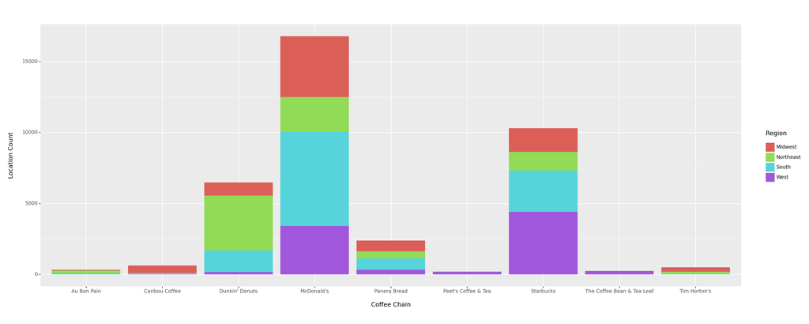

```
<Figure Size: (2000 x 800)>
```

```python
from plotnine import *

plot = (ggplot(rest_loc, aes(x='Coffee Chain', y= 'Location Count', fill = 'Region'))
        + geom_bar(stat='identity', position= 'stack')
        + theme(figure_size=(20, 8))
)
plot
```

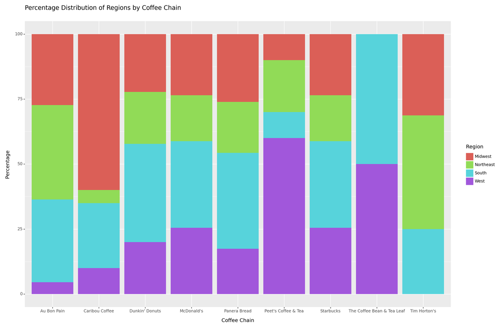

```
<Figure Size: (1500 x 1000)>
```

```python
chain_region_melted = chain_region_distribution.reset_index().melt(id_vars='Coffee Chain',
                                                                  value_name='Percentage',
                                                                  var_name='Region')


# Create the plot for distribution of regions for each coffee chain
plot2 = (ggplot(chain_region_melted, aes(x='Coffee Chain', y='Percentage', fill='Region'))
                           + geom_bar(stat='identity', position='stack')
                           + labs(title="Percentage Distribution of Regions by Coffee Chain",
                                  y="Percentage", x="Coffee Chain")
                           + theme(figure_size=(15, 10)))

plot2
```

### Does the distribution of each chain’s stores match population distribution, by both state/region?

As we can see in the graph below, most restaurants do not necessarily match their number of stores to toal population for that region. Starubucks does it for 3 regions but we see a lot more locations per capita on the west. There could be numerous factors affecting this decision by the chains, such as different life style or household income per region.

```
FutureWarning: Indexing with multiple keys (implicitly converted to a tuple of keys) will be deprecated, use a list instead.
```

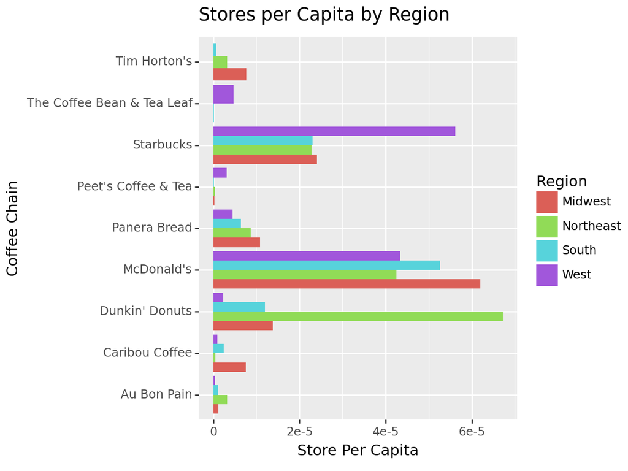

```
<Figure Size: (640 x 480)>
```

```python
store_per_capita_region = rest_loc.groupby(['Coffee Chain', 'Region'])['Location Count', 'Population'].sum().reset_index()

store_per_capita_region['Store per Capita'] = store_per_capita_region['Location Count'] / store_per_capita_region['Population']


plot3 = (ggplot(store_per_capita_region, aes(x='Coffee Chain', y='Store per Capita', fill='Region'))
                      + geom_bar(stat='identity', position='dodge')
                      + coord_flip()
                      + labs(title="Stores per Capita by Region",
                             y="Store Per Capita", x="Coffee Chain"))

plot3
```

### Do the financial data match what you’d expect based on the number and locations of the stores? Why or why not?

As we can see, the total number of locations does not necessarily correlate to stock price, but it is important to keep in mind that this could also be to a poor chosen metric on earlier steps. Maybe we should have used total market Cap as the metric since one company could be cheap but have much higher total valuation.

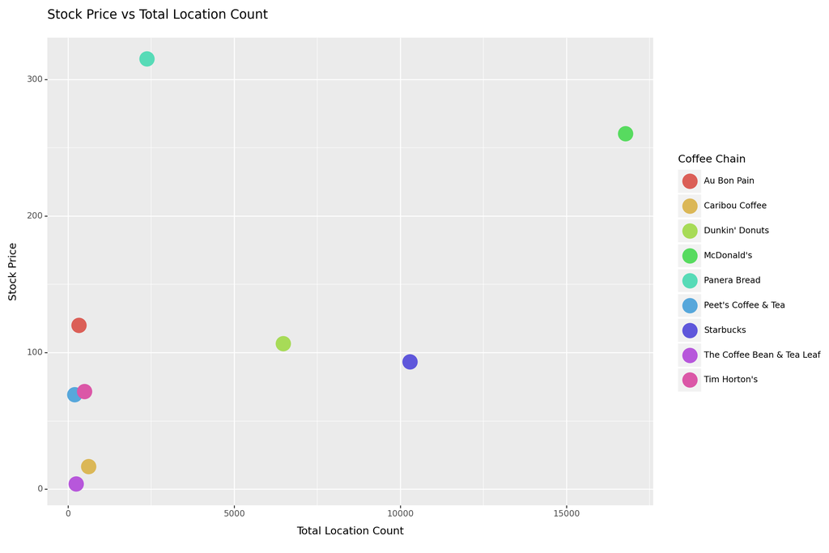

```
<Figure Size: (1200 x 800)>
```

```python
total_locations_chain = rest_loc.groupby('Coffee Chain').agg({'Location Count': 'sum', 'Stock Price': 'first'}).reset_index()

plot4 = (ggplot(total_locations_chain, aes(x='Location Count', y='Stock Price', color='Coffee Chain'))
                               + geom_point( size=8)
                               + labs(title="Stock Price vs Total Location Count",
                                      y="Stock Price", x="Total Location Count")
                               + theme(figure_size=(12, 8)))

plot4
```

# **Automate**

From Question 1 since i had it done there

```python
def rest_locations(url):
    response = requests.get(url)
    soup = BeautifulSoup(response.content, "html.parser")
    locations = soup.find_all("li", attrs={"class": ""})

    rest_name = soup.find("meta", attrs={"property":"og:title", "name":'og:title'})
    restaurant_name = rest_name.get("content")

    rows = []

    for location in locations:
        a_text = location.get_text()
        before = re.findall(r".+(?= " + re.escape(restaurant_name) + " locations )", a_text)
        after = re.findall(r"(?<=locations ).+", a_text)

        if before and after:
            state = before[0]
            numloc = after[0]
            numloc = numloc.replace("(","").replace(")","")

            rows.append({
                "state": state,
                "Number_of_Locations": numloc,
                "Restaurant_Name": restaurant_name
            })

    return pd.DataFrame(rows)
```